# UTS2024_IF540L_Kelas_H_Kelompok_7

### Dataset Overview

| Feature | Unique Values | Most Frequent Value | Frequency of Most Frequent Value |
| --- | --- | --- | --- |
| **title** | 38729 | Factbox: Trump fills top jobs for his administration | 14 |
| **text** | 38646 | Text content of an article repeated 627 times | 627 |
| **subject** | 8 | politicsNews | 11272 |
| **date** | 2397 | December 20, 2017 | 182 |
| **label** | 2 (0 or 1) | 0 (Fake) | - |

### **Mean = 0,477015 mengimplikasikan bahwa sekitar 47,7% artikelnya asli (1) dan sisanya (~52,3%) palsu (0).**

##### Hal ini menunjukkan bahwa kumpulan data tersebut relatif seimbang, meskipun jumlah artikel berita palsu sedikit lebih banyak daripada berita asli.

### **std (Standard Deviation): Standard deviation yang dimiliki adalah 0,499477. Untuk klasifikasi biner, deviasi standar mengukur seberapa banyak variasi antara nilai 0 dan 1:**

##### Nilai yang mendekati 0,5 menunjukkan adanya pembagian yang hampir merata antara 0 dan 1. Karena nilai ini mendekati 0,5, hal ini menunjukkan bahwa terdapat campuran yang baik dari kedua kelas.

### **25%, 50%, and 75% (Quartiles):**

##### 25% and 50% (median): Keduanya adalah 0, yang berarti setidaknya 50% artikel diberi label 0 (palsu).

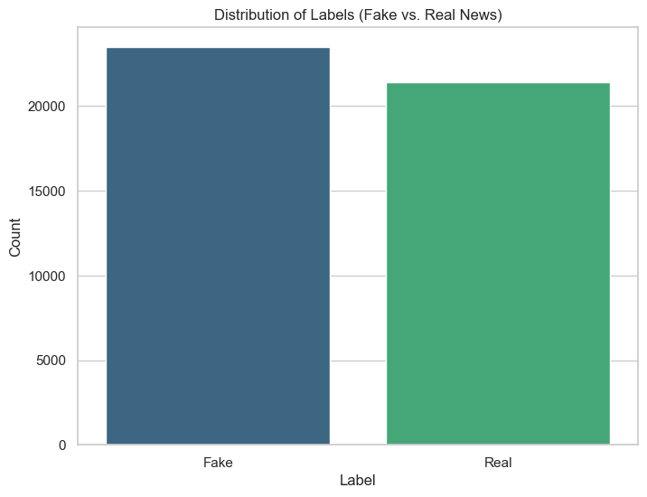

```python
# Plotting for the distribution of labels (fake vs. real news)
plt.figure(figsize=(8, 6))
sns.countplot(x='label', hue='label', data=df, palette='viridis', legend=False)
plt.xlabel('Label')
plt.ylabel('Count')
plt.title('Distribution of Labels (Fake vs. Real News)')
plt.xticks(ticks=[0, 1], labels=['Fake', 'Real'])
plt.show()
```

##### Bar chart ini membantu kita melihat distribusi berita palsu dan asli dalam kumpulan data. Bagan ini menunjukkan bahwa jumlah berita palsu dan asli hampir sama, yang berarti datanya cukup seimbang. Keseimbangan ini bermanfaat saat melatih model pembelajaran mesin, karena mencegah model menjadi bias terhadap satu kelas daripada kelas lainnya.

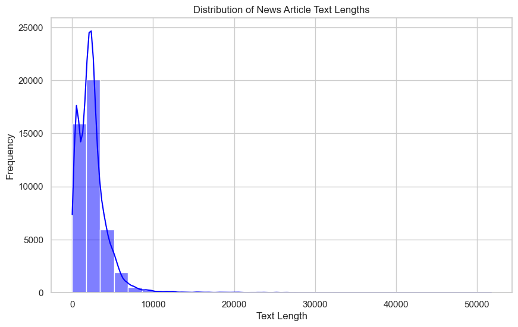

```python
# New column for the length of the text
df['text_length'] = df['text'].apply(len)

# Plotting for distribution of text lengths
plt.figure(figsize=(10, 6))
sns.histplot(df['text_length'], kde=True, color='blue', bins=30)
plt.xlabel('Text Length')
plt.ylabel('Frequency')
plt.title('Distribution of News Article Text Lengths')
plt.show()
```